# Fund_Performance

```
The option 'mode.use_inf_as_null' is not available in this pandas version.
```

```
Stat                 Bandhan Nifty 50    DSP Nifty 50 Eq.Wt    JM Flexicap    PPFAS Flexi Cap    Nippon Multi Cap    ICICI Multi-Asset    HDFC Bal. Adv.    Kotak Equity Arbitrage    SBI Magnum Gilt
-------------------  ------------------  --------------------  -------------  -----------------  ------------------  -------------------  ----------------  ------------------------  -----------------
Start                2024-01-01          2024-01-01            2024-01-01     2024-01-01         2024-01-01          2024-01-01           2024-01-01        2024-01-01                2024-01-01
End                  2024-12-31          2024-12-31            2024-12-31     2024-12-31         2024-12-31          2024-12-31           2024-12-31        2024-12-31                2024-12-31
Risk-free rate       0.00%               0.00%                 0.00%          0.00%              0.00%               0.00%                0.00%             0.00%                     0.00%

Total Return         9.69%               10.12%                34.72%         24.43%             26.42%              16.90%               16.99%            8.37%                     9.60%
Daily Sharpe         0.76                0.77                  1.83           2.10               1.67                2.17                 1.55              8.26                      3.87
Daily Sortino        1.16                1.19                  2.63           3.26               2.45                3.41                 2.13              21.77                     6.65
CAGR                 9.70%               10.13%                34.75%         24.44%             26.44%              16.91%               17.00%            8.38%                     9.60%
Max Drawdown         -10.86%             -13.56%               -9.29%         -4.88%             -8.55%              -5.53%               -6.11%            -0.16%                    -0.92%
Calmar Ratio         0.89                0.75                  3.74           5.01               3.09                3.06                 2.78              51.21                     10.49

MTD                  -2.03%              -1.90%                0.73%          1.05%              -0.83%              -1.17%               -0.73%            0.69%                     0.49%
3m                   -8.32%              -11.95%               -4.11%         -1.06%             -5.46%              -4.58%               -2.96%            2.00%                     0.59%
6m                   -1.27%              -2.77%                2.08%          7.00%              1.51%               2.13%                1.40%             3.82%                     4.27%
YTD                  9.69%               10.12%                34.72%         24.43%             26.42%              16.90%               16.99%            8.37%                     9.60%
1Y                   -                   -                     -              -                  -                   -                    -                 -                         -
3Y (ann.)            -                   -                     -              -                  -                   -                    -                 -                         -
5Y (ann.)            -                   -                     -              -                  -                   -                    -                 -                         -
10Y (ann.)           -                   -                     -              -                  -                   -                    -                 -                         -
Since Incep. (ann.)  9.70%               10.13%                34.75%         24.44%             26.44%              16.91%               17.00%            8.38%                     9.60%

Daily Sharpe         0.76                0.77                  1.83           2.10               1.67                2.17                 1.55              8.26                      3.87
```

[output cut: 32 more lines]

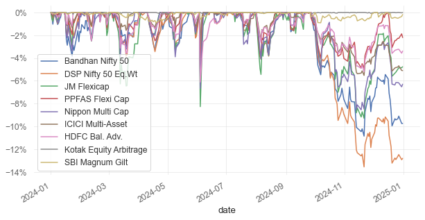

```
Stat                 Bandhan Nifty 50    DSP Nifty 50 Eq.Wt    JM Flexicap    PPFAS Flexi Cap    Nippon Multi Cap    ICICI Multi-Asset    HDFC Bal. Adv.    Kotak Equity Arbitrage    SBI Magnum Gilt
-------------------  ------------------  --------------------  -------------  -----------------  ------------------  -------------------  ----------------  ------------------------  -----------------
Start                2023-01-02          2023-01-02            2023-01-02     2023-01-02         2023-01-02          2023-01-02           2023-01-02        2023-01-02                2023-01-02
End                  2023-12-29          2023-12-29            2023-12-29     2023-12-29         2023-12-29          2023-12-29           2023-12-29        2023-12-29                2023-12-29
Risk-free rate       0.00%               0.00%                 0.00%          0.00%              0.00%               0.00%                0.00%             0.00%                     0.00%

Total Return         20.48%              29.91%                41.09%         37.49%             38.34%              24.17%               31.36%            7.95%                     8.10%
Daily Sharpe         2.10                2.95                  3.65           4.11               3.59                4.07                 4.32              9.71                      4.58
Daily Sortino        3.82                5.36                  6.21           7.83               5.80                8.16                 7.69              24.32                     8.94
CAGR                 20.74%              30.32%                41.66%         38.01%             38.87%              24.49%               31.78%            8.05%                     8.20%
Max Drawdown         -7.02%              -7.60%                -6.07%         -4.12%             -6.67%              -2.40%               -3.51%            -0.19%                    -0.74%
Calmar Ratio         2.96                3.99                  6.86           9.23               5.83                10.22                9.04              42.46                     11.04

MTD                  7.92%               8.02%                 7.26%          4.83%              5.80%               3.99%                6.62%             0.67%                     1.08%
3m                   10.79%              13.56%                14.46%         11.78%             9.50%               8.67%                11.42%            1.81%                     2.08%
6m                   15.05%              20.81%                27.06%         18.48%             22.50%              16.98%               22.51%            3.98%                     3.02%
YTD                  20.48%              29.91%                41.09%         37.49%             38.34%              24.17%               31.36%            7.95%                     8.10%
1Y                   -                   -                     -              -                  -                   -                    -                 -                         -
3Y (ann.)            -                   -                     -              -                  -                   -                    -                 -                         -
5Y (ann.)            -                   -                     -              -                  -                   -                    -                 -                         -
10Y (ann.)           -                   -                     -              -                  -                   -                    -                 -                         -
Since Incep. (ann.)  20.74%              30.32%                41.66%         38.01%             38.87%              24.49%               31.78%            8.05%                     8.20%

Daily Sharpe         2.10                2.95                  3.65           4.11               3.59                4.07                 4.32              9.71                      4.58
```

[output cut: 32 more lines]

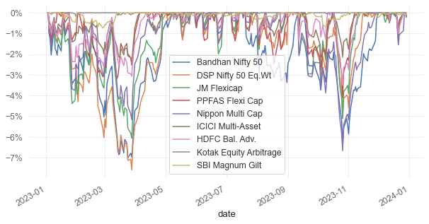

```
Stat                 Bandhan Nifty 50    DSP Nifty 50 Eq.Wt    JM Flexicap    PPFAS Flexi Cap    Nippon Multi Cap    ICICI Multi-Asset    HDFC Bal. Adv.    Kotak Equity Arbitrage    SBI Magnum Gilt
-------------------  ------------------  --------------------  -------------  -----------------  ------------------  -------------------  ----------------  ------------------------  -----------------
Start                2022-01-03          2022-01-03            2022-01-03     2022-01-03         2022-01-03          2022-01-03           2022-01-03        2022-01-03                2022-01-03
End                  2022-12-30          2022-12-30            2022-12-30     2022-12-30         2022-12-30          2022-12-30           2022-12-30        2022-12-30                2022-12-30
Risk-free rate       0.00%               0.00%                 0.00%          0.00%              0.00%               0.00%                0.00%             0.00%                     0.00%

Total Return         4.14%               6.22%                 6.93%          -6.51%             13.59%              16.63%               18.24%            5.10%                     4.71%
Daily Sharpe         0.33                0.45                  0.48           -0.34              0.83                1.63                 1.56              5.64                      2.20
Daily Sortino        0.54                0.73                  0.77           -0.54              1.30                2.72                 2.58              13.12                     4.15
CAGR                 4.19%               6.29%                 7.02%          -6.59%             13.76%              16.84%               18.48%            5.16%                     4.77%
Max Drawdown         -15.69%             -15.55%               -17.89%        -17.49%            -15.75%             -8.65%               -8.41%            -0.14%                    -1.11%
Calmar Ratio         0.27                0.40                  0.39           -0.38              0.87                1.95                 2.20              37.88                     4.29

MTD                  -3.48%              -3.10%                -1.62%         -2.83%             -2.38%              -0.16%               -0.92%            0.75%                     0.49%
3m                   6.01%               4.61%                 7.02%          2.29%              2.26%               7.35%                7.48%             1.60%                     2.12%
6m                   15.28%              17.20%                18.44%         8.98%              20.82%              14.48%               16.96%            2.67%                     4.06%
YTD                  4.14%               6.22%                 6.93%          -6.51%             13.59%              16.63%               18.24%            5.10%                     4.71%
1Y                   -                   -                     -              -                  -                   -                    -                 -                         -
3Y (ann.)            -                   -                     -              -                  -                   -                    -                 -                         -
5Y (ann.)            -                   -                     -              -                  -                   -                    -                 -                         -
10Y (ann.)           -                   -                     -              -                  -                   -                    -                 -                         -
Since Incep. (ann.)  4.19%               6.29%                 7.02%          -6.59%             13.76%              16.84%               18.48%            5.16%                     4.77%

Daily Sharpe         0.33                0.45                  0.48           -0.34              0.83                1.63                 1.56              5.64                      2.20
```

[output cut: 32 more lines]

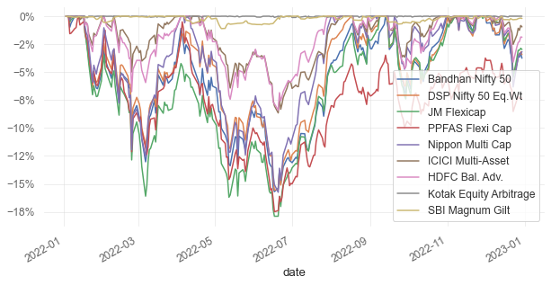

```
Stat                 Bandhan Nifty 50    DSP Nifty 50 Eq.Wt    JM Flexicap    PPFAS Flexi Cap    Nippon Multi Cap    ICICI Multi-Asset    HDFC Bal. Adv.    Kotak Equity Arbitrage    SBI Magnum Gilt
-------------------  ------------------  --------------------  -------------  -----------------  ------------------  -------------------  ----------------  ------------------------  -----------------
Start                2021-01-01          2021-01-01            2021-01-01     2021-01-01         2021-01-01          2021-01-01           2021-01-01        2021-01-01                2021-01-01
End                  2021-12-31          2021-12-31            2021-12-31     2021-12-31         2021-12-31          2021-12-31           2021-12-31        2021-12-31                2021-12-31
Risk-free rate       0.00%               0.00%                 0.00%          0.00%              0.00%               0.00%                0.00%             0.00%                     0.00%

Total Return         24.67%              33.63%                33.28%         46.76%             48.50%              35.03%               26.43%            4.61%                     3.47%
Daily Sharpe         1.53                1.98                  1.88           3.28               2.50                2.48                 1.88              5.91                      2.56
Daily Sortino        2.55                3.17                  3.14           5.91               4.02                4.09                 3.00              12.23                     3.88
CAGR                 24.77%              33.76%                33.41%         46.95%             48.71%              35.17%               26.53%            4.63%                     3.48%
Max Drawdown         -9.96%              -11.05%               -8.57%         -5.14%             -9.64%              -6.68%               -8.16%            -0.17%                    -1.45%
Calmar Ratio         2.49                3.06                  3.90           9.13               5.05                5.26                 3.25              26.61                     2.40

MTD                  2.16%               2.75%                 2.53%          2.41%              1.94%               1.11%                0.81%             0.20%                     0.18%
3m                   -1.45%              -1.49%                -0.04%         4.01%              0.39%               0.83%                -1.61%            1.06%                     0.55%
6m                   10.62%              10.39%                14.64%         20.12%             17.04%              14.00%               6.64%             2.03%                     2.29%
YTD                  24.67%              33.63%                33.28%         46.76%             48.50%              35.03%               26.43%            4.61%                     3.47%
1Y                   -                   -                     -              -                  -                   -                    -                 -                         -
3Y (ann.)            -                   -                     -              -                  -                   -                    -                 -                         -
5Y (ann.)            -                   -                     -              -                  -                   -                    -                 -                         -
10Y (ann.)           -                   -                     -              -                  -                   -                    -                 -                         -
Since Incep. (ann.)  24.77%              33.76%                33.41%         46.95%             48.71%              35.17%               26.53%            4.63%                     3.48%

Daily Sharpe         1.53                1.98                  1.88           3.28               2.50                2.48                 1.88              5.91                      2.56
```

[output cut: 32 more lines]

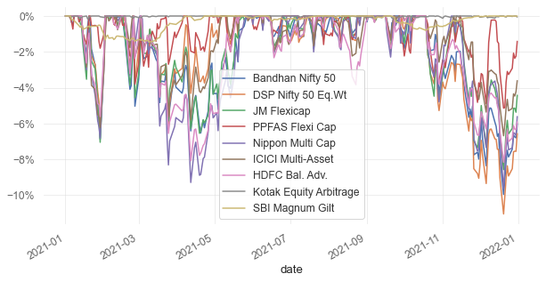

```
Stat                 Bandhan Nifty 50    DSP Nifty 50 Eq.Wt    JM Flexicap    PPFAS Flexi Cap    Nippon Multi Cap    ICICI Multi-Asset    HDFC Bal. Adv.    Kotak Equity Arbitrage    SBI Magnum Gilt
-------------------  ------------------  --------------------  -------------  -----------------  ------------------  -------------------  ----------------  ------------------------  -----------------
Start                2020-01-01          2020-01-01            2020-01-01     2020-01-01         2020-01-01          2020-01-01           2020-01-01        2020-01-01                2020-01-01
End                  2020-12-31          2020-12-31            2020-12-31     2020-12-31         2020-12-31          2020-12-31           2020-12-31        2020-12-31                2020-12-31
Risk-free rate       0.00%               0.00%                 0.00%          0.00%              0.00%               0.00%                0.00%             0.00%                     0.00%

Total Return         16.34%              16.31%                12.12%         33.28%             0.74%               10.42%               7.88%             4.82%                     11.95%
Daily Sharpe         0.65                0.66                  0.54           1.44               0.19                0.56                 0.43              3.59                      2.30
Daily Sortino        0.93                0.93                  0.75           2.14               0.26                0.81                 0.60              6.10                      4.10
CAGR                 16.35%              16.32%                12.13%         33.30%             0.75%               10.42%               7.88%             4.83%                     11.96%
Max Drawdown         -37.58%             -38.66%               -34.95%        -31.20%            -41.03%             -30.61%              -33.26%           -0.57%                    -2.86%
Calmar Ratio         0.44                0.42                  0.35           1.07               0.02                0.34                 0.24              8.49                      4.19

MTD                  7.76%               8.08%                 6.93%          4.55%              7.72%               8.65%                7.92%             0.43%                     0.45%
3m                   24.37%              27.04%                27.86%         12.52%             23.68%              19.74%               24.68%            1.02%                     3.04%
6m                   36.37%              38.20%                31.24%         33.38%             35.15%              21.40%               27.67%            1.73%                     3.39%
YTD                  16.34%              16.31%                12.12%         33.28%             0.74%               10.42%               7.88%             4.82%                     11.95%
1Y                   -                   -                     -              -                  -                   -                    -                 -                         -
3Y (ann.)            -                   -                     -              -                  -                   -                    -                 -                         -
5Y (ann.)            -                   -                     -              -                  -                   -                    -                 -                         -
10Y (ann.)           -                   -                     -              -                  -                   -                    -                 -                         -
Since Incep. (ann.)  16.35%              16.32%                12.13%         33.30%             0.75%               10.42%               7.88%             4.83%                     11.96%

Daily Sharpe         0.65                0.66                  0.54           1.44               0.19                0.56                 0.43              3.59                      2.30
```

[output cut: 32 more lines]

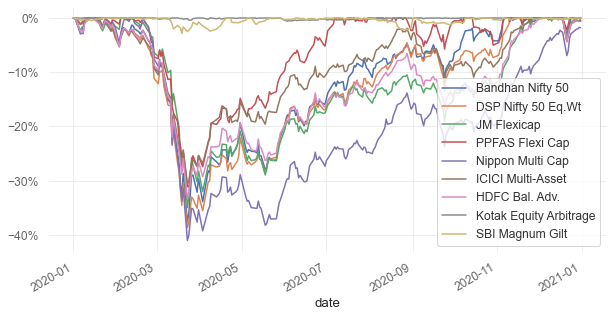

```
Stat                 Bandhan Nifty 50    DSP Nifty 50 Eq.Wt    JM Flexicap    PPFAS Flexi Cap    Nippon Multi Cap    ICICI Multi-Asset    HDFC Bal. Adv.    Kotak Equity Arbitrage    SBI Magnum Gilt
-------------------  ------------------  --------------------  -------------  -----------------  ------------------  -------------------  ----------------  ------------------------  -----------------
Start                2019-01-01          2019-01-01            2019-01-01     2019-01-01         2019-01-01          2019-01-01           2019-01-01        2019-01-01                2019-01-01
End                  2019-12-31          2019-12-31            2019-12-31     2019-12-31         2019-12-31          2019-12-31           2019-12-31        2019-12-31                2019-12-31
Risk-free rate       0.00%               0.00%                 0.00%          0.00%              0.00%               0.00%                0.00%             0.00%                     0.00%

Total Return         12.54%              3.57%                 17.10%         14.93%             2.69%               8.32%                7.07%             6.62%                     13.83%
Daily Sharpe         0.96                0.31                  1.34           1.68               0.25                0.82                 0.60              7.14                      3.83
Daily Sortino        1.89                0.55                  2.98           3.08               0.48                1.45                 1.10              17.94                     7.02
CAGR                 12.58%              3.58%                 17.17%         14.99%             2.70%               8.35%                7.09%             6.65%                     13.88%
Max Drawdown         -10.79%             -15.38%               -5.43%         -5.31%             -17.57%             -8.41%               -11.68%           -0.12%                    -1.26%
Calmar Ratio         1.17                0.23                  3.16           2.82               0.15                0.99                 0.61              53.41                     11.02

MTD                  0.90%               0.02%                 1.19%          0.55%              0.38%               1.15%                0.18%             0.31%                     0.74%
3m                   6.10%               5.60%                 3.36%          5.39%              4.75%               5.43%                4.51%             1.41%                     2.19%
6m                   3.78%               -0.94%                11.38%         6.39%              -2.53%              1.63%                -2.28%            3.06%                     5.27%
YTD                  12.54%              3.57%                 17.10%         14.93%             2.69%               8.32%                7.07%             6.62%                     13.83%
1Y                   -                   -                     -              -                  -                   -                    -                 -                         -
3Y (ann.)            -                   -                     -              -                  -                   -                    -                 -                         -
5Y (ann.)            -                   -                     -              -                  -                   -                    -                 -                         -
10Y (ann.)           -                   -                     -              -                  -                   -                    -                 -                         -
Since Incep. (ann.)  12.58%              3.58%                 17.17%         14.99%             2.70%               8.35%                7.09%             6.65%                     13.88%

Daily Sharpe         0.96                0.31                  1.34           1.68               0.25                0.82                 0.60              7.14                      3.83
```

[output cut: 32 more lines]

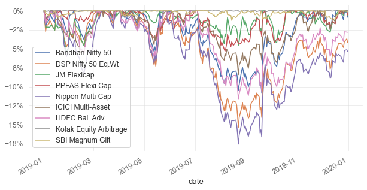

```
Stat                 Bandhan Nifty 50    DSP Nifty 50 Eq.Wt    JM Flexicap    PPFAS Flexi Cap    Nippon Multi Cap    ICICI Multi-Asset    HDFC Bal. Adv.    Kotak Equity Arbitrage    SBI Magnum Gilt
-------------------  ------------------  --------------------  -------------  -----------------  ------------------  -------------------  ----------------  ------------------------  -----------------
Start                2018-01-01          2018-01-01            2018-01-01     2018-01-01         2018-01-01          2018-01-01           2018-01-01        2018-01-01                2018-01-01
End                  2018-12-31          2018-12-31            2018-12-31     2018-12-31         2018-12-31          2018-12-31           2018-12-31        2018-12-31                2018-12-31
Risk-free rate       0.00%               0.00%                 0.00%          0.00%              0.00%               0.00%                0.00%             0.00%                     0.00%

Total Return         5.49%               -4.25%                -3.88%         0.22%              -1.14%              -0.86%               0.79%             6.80%                     5.76%
Daily Sharpe         0.50                -0.26                 -0.21          0.07               -0.00               -0.06                0.13              6.63                      1.62
Daily Sortino        0.82                -0.42                 -0.34          0.11               -0.01               -0.10                0.23              14.47                     2.92
CAGR                 5.51%               -4.27%                -3.89%         0.22%              -1.15%              -0.86%               0.79%             6.83%                     5.78%
Max Drawdown         -14.22%             -15.13%               -16.85%        -12.16%            -17.37%             -9.25%               -11.25%           -0.18%                    -2.57%
Calmar Ratio         0.39                -0.28                 -0.23          0.02               -0.07               -0.09                0.07              37.29                     2.24

MTD                  -0.10%              1.27%                 0.29%          -0.41%             2.59%               2.80%                2.50%             0.36%                     1.67%
3m                   -0.43%              -1.23%                2.59%          -4.14%             7.43%               0.75%                3.40%             1.59%                     4.32%
6m                   1.94%               -1.26%                -0.75%         -1.77%             9.91%               3.69%                6.01%             3.35%                     5.54%
YTD                  5.49%               -4.25%                -3.88%         0.22%              -1.14%              -0.86%               0.79%             6.80%                     5.76%
1Y                   -                   -                     -              -                  -                   -                    -                 -                         -
3Y (ann.)            -                   -                     -              -                  -                   -                    -                 -                         -
5Y (ann.)            -                   -                     -              -                  -                   -                    -                 -                         -
10Y (ann.)           -                   -                     -              -                  -                   -                    -                 -                         -
Since Incep. (ann.)  5.51%               -4.27%                -3.89%         0.22%              -1.15%              -0.86%               0.79%             6.83%                     5.78%

Daily Sharpe         0.50                -0.26                 -0.21          0.07               -0.00               -0.06                0.13              6.63                      1.62
```

[output cut: 32 more lines]

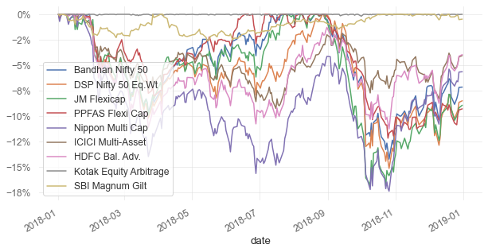

- **Ulcer Index**

A higher Ulcer Index value indicates greater downside risk and potential for larger drawdowns

- **Serenity Index**

A higher Serenity Index generally indicates a fund with lower downside risk. This means the fund's returns are more consistent and less volatile, especially during market downturns.

- **Gain/Pain Ratio**

A performance metric used to evaluate the profitability of a trading strategy. e.g., GPR of 2.33, suggests that for every dollar of loss, the trader gains $2.33 in profit.

- **Common Sense Ratio**

A higher Common Sense Ratio suggests a more robust and potentially more profitable trading strategy. It indicates that the strategy not only generates profits but also has a tendency to produce larger winning trades while minimizing the impact of losing trades.

- **Outlier Win Ratio**

A higher OWR suggests a strategy that produces a relatively high frequency of significantly large winning trades

- **Recovery Factor**

A higher recovery factor indicates that the fund recovers from losses more rapidly. This is a desirable trait for investors, as it suggests resilience and the potential for stronger long-term performance.

- **Tail Ratio**

A higher Tail Ratio suggests a strategy that produces a relatively high frequency of significantly large winning trades.

```
Stat                 Bandhan Nifty 50    DSP Nifty 50 Eq.Wt    JM Flexicap    PPFAS Flexi Cap    Nippon Multi Cap    ICICI Multi-Asset    HDFC Bal. Adv.    Kotak Equity Arbitrage    SBI Magnum Gilt
-------------------  ------------------  --------------------  -------------  -----------------  ------------------  -------------------  ----------------  ------------------------  -----------------
Start                2019-01-01          2019-01-01            2019-01-01     2019-01-01         2019-01-01          2019-01-01           2019-01-01        2019-01-01                2019-01-01
End                  2019-12-31          2019-12-31            2019-12-31     2019-12-31         2019-12-31          2019-12-31           2019-12-31        2019-12-31                2019-12-31
Risk-free rate       0.00%               0.00%                 0.00%          0.00%              0.00%               0.00%                0.00%             0.00%                     0.00%

Total Return         12.54%              3.57%                 17.10%         14.93%             2.69%               8.32%                7.07%             6.62%                     13.83%
Daily Sharpe         0.96                0.31                  1.34           1.68               0.25                0.82                 0.60              7.14                      3.83
Daily Sortino        1.89                0.55                  2.98           3.08               0.48                1.45                 1.10              17.94                     7.02
CAGR                 12.58%              3.58%                 17.17%         14.99%             2.70%               8.35%                7.09%             6.65%                     13.88%
Max Drawdown         -10.79%             -15.38%               -5.43%         -5.31%             -17.57%             -8.41%               -11.68%           -0.12%                    -1.26%
Calmar Ratio         1.17                0.23                  3.16           2.82               0.15                0.99                 0.61              53.41                     11.02

MTD                  0.90%               0.02%                 1.19%          0.55%              0.38%               1.15%                0.18%             0.31%                     0.74%
3m                   6.10%               5.60%                 3.36%          5.39%              4.75%               5.43%                4.51%             1.41%                     2.19%
6m                   3.78%               -0.94%                11.38%         6.39%              -2.53%              1.63%                -2.28%            3.06%                     5.27%
YTD                  12.54%              3.57%                 17.10%         14.93%             2.69%               8.32%                7.07%             6.62%                     13.83%
1Y                   -                   -                     -              -                  -                   -                    -                 -                         -
3Y (ann.)            -                   -                     -              -                  -                   -                    -                 -                         -
5Y (ann.)            -                   -                     -              -                  -                   -                    -                 -                         -
10Y (ann.)           -                   -                     -              -                  -                   -                    -                 -                         -
Since Incep. (ann.)  12.58%              3.58%                 17.17%         14.99%             2.70%               8.35%                7.09%             6.65%                     13.88%

Daily Sharpe         0.96                0.31                  1.34           1.68               0.25                0.82                 0.60              7.14                      3.83
```

[output cut: 32 more lines]

```
            Bandhan Nifty 50  DSP Nifty 50 Eq.Wt  JM Flexicap  PPFAS Flexi Cap  Nippon Multi Cap  ICICI Multi-Asset  HDFC Bal. Adv.  Kotak Equity Arbitrage  SBI Magnum Gilt
date
2024-12-31          9.968085             9.82198      13.7472        13.571656         12.576036           10.73103        10.90646                4.310808         5.513947
```